# Homework For StatComp

22001

2022-12-06

###A-22001-2022-09-09

## Question

Use knitr to produce at least 3 examples (texts, figures, tables)

## Answer

1.There is a time series data:

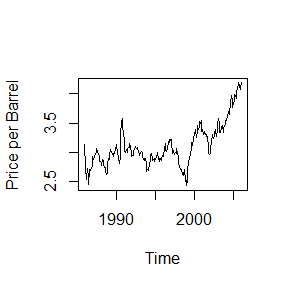

```r
data(oil.price)
plot(log(oil.price), ylab='Price per Barrel',type='l')
```

The plots show that this time series is nonstationary,so we may consider difference.

We choose the first differenc for the data, we can see that:

[figure not shown]

```r
knitr::kable(head(trees))
```

| Girth | Height | Volume |
| --- | --- | --- |
| 8.3 | 70 | 10.3 |
| 8.6 | 65 | 10.3 |
| 8.8 | 63 | 10.2 |
| 10.5 | 72 | 16.4 |
| 10.7 | 81 | 18.8 |
| 10.8 | 83 | 19.7 |

3.R is a free software environment for statistical computing and graphics. It compiles and runs on a wide variety of UNIX platforms, Windows and macOS.

See the R project web page on “What is R?” for more information.

Sources and binaries for R and for contributed packages are available from the Comprehensive R Archive Network (CRAN).

###A-22001-2022-09-15

## Question 1

The Pareto(a, b) distribution has cdf
$$F(x)=1 − (\frac{b}{x})^ a$$
$x ≥ b > 0,a> 0$. Derive the probability inverse transformation $F^{-1}(U)$ and use the inverse transform method to simulate a random sample from the Pareto(2, 2) distribution. Graph the density histogram of the sample with the Pareto(2, 2) density superimposed for comparison.

## Answer 1

We use the inverse transform method to simulate a random sample from the Pareto(2, 2) distribution. The method can be summarized as follows:

1.We can derive the inverse function $F_{X}^{−1}(u)=\frac{b} {(1-u)^{\frac{1}{a}}}$.

2. Write a command or function to compute $F_{X}^{−1}(u)$.
3. For each random variate required:

$(a)$ Generate a random u from Uniform(0,1).

$(b)$ Deliver $x = F_{X}^{−1}(u)$.

So we can considerthe random sample x generated by the above method follows Pareto(2, 2).

The codes as follow:

```r
set.seed(1234)
n <- 500
a<-2
b<-2
u <- runif(n)
x <- b/(1-u)^(1/a)
```

Then,we graph the density histogram of the sample with the Pareto(2, 2) density superimposed for comparison:

We can derive the Pareto(2, 2) density function $f(x)=8y^{-3}$:

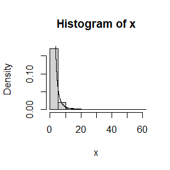

```r
hist(x, prob = TRUE) #density histogram of sample
y <- seq(0, 100, 0.01)
lines(y, 8*y^(-3)) #density curve f(x)
```

This plot shows that the sample generated by the inverse transform method may follow the Pareto(2, 2).

## Question 2

Write a function to generate a random sample of size n from the Beta(a, b) distribution by the acceptance-rejection method. Generate a random sample of size 1000 from the Beta(3,2) distribution. Graph the histogram of the sample with the theoretical Beta(3,2) density superimposed.

## Answer 2

We use the acceptance-rejection method to simulate a random sample from the Beta(a, b) distribution. The method can be summarized as follows:

1. Find a random variable Y with density g satisfying f(t)/g(t) ≤ c, for all t such that f(t) > 0. Provide a method to generate random Y.
2. For each random variate required:

$(a)$ Generate a random y from the distribution with density g.

$(b)$ Generate a random u from the Uniform(0, 1) distribution.

$(c)$ If u<f(y)/(cg(y)) accept y and deliver x = y; otherwise reject y and repeat from step (2a).

We know that the density function of Beta(a, b) is $f(x)=\frac{\Gamma(a+b)}{\Gamma(a)\Gamma(b)}x^{a-1}(1-x)^{b-1}$.

So we choose g(x)=1 for 0<x<1;and for some suitable c ;cg(x)=c can be used to generate a random sample of size n from the Beta(a, b) distribution by the acceptance-rejection method.

For the Beta(3,2),the density function is $f(x)=12x^2(1-x)$,with $f^{'}(x)=0$.We can get the $\max f(x)=\frac{16}{9}$.

So we choose $c=\frac{16}{9}$.

```r
n <- 200
k <- 0 #counter for accepted
y <- numeric(n)
while (k < n) {
u <- runif(1)
x <- runif(1) #random variate from g
if (27/4*(x^2) * (1-x) > u) {
#we accept x
k <- k + 1
y[k] <- x
} }
```

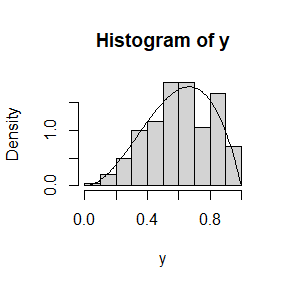

```r
hist(y, prob = TRUE) #density histogram of sample
d <- seq(0, 1, 0.01)
m<-dbeta(d,3,2)
lines(d,m) #density curve f(x)
```

We may obtain that the density histogram of sample approximately match the theoretical density curve f(x).

## Question 3

Simulate a continuous Exponential-Gamma mixture. Suppose that the rate parameter $\Lambda$ has $Gamma(r, β)$ distribution and Y has $Exp(Λ) $distribution. That is, $(Y |Λ = λ)$ ∼ $f_Y (y|λ)$ = $λe^{−λy}$. Generate 1000 random observations from this mixture with r = 4 and$ β = 2$.

## Answer 3

```r
set.seed(1234)
#generate a Exponential-Gamma mixture
n <- 200
r <- 4
beta <- 2
lambda <- rgamma(n, r, beta) #lambda is random
#now supply the sample of lambda’s as the Poisson mean
x <- rgamma(n, 1,lambda) #the mixture
```

## Question 4

It can be shown that the mixture in Exercise 3.12 has a Pareto distribution with cdf
$$F(y)=1 − (\frac{ β}{β
+ y })^ r$$
$y ≥ 0.$ (This is an alternative parameterization of the Pareto cdf given in Exercise 3.3.) Generate 1000 random observations from the mixture with r = 4 and β = 2. Compare the empirical and theoretical (Pareto) distributions by graphing the density histogram of the sample and superimposing the Pareto density curve.

## Answer 4

We can derive that the Pareto density function $f(x)=64(2+y)^{-5}$ for r = 4 and β = 2.

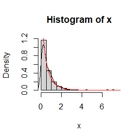

```r
set.seed(1234)
#generate a Exponential-Gamma mixture
n <- 200
r <- 4
beta <- 2
lambda <- rgamma(n, r, beta) #lambda is random
#now supply the sample of lambda’s as the Poisson mean
x <- rgamma(n, 1,lambda) #the mixture
#compare with Pareto
hist(x,breaks=12,prob = TRUE)
lines(density(x))
d <- seq(0, 1000, 0.01)
lines(d,64*(2+d)^(-5),col='red')
```

The black line and density histogram is the empirical Pareto distribution, and the red line is theoretical Pareto distribution.We may obtain that the empirical Pareto distribution approximately match the theoretical Pareto(4,2) distribution.

###A-22001-2022-09-23

## Question 1

For $n = 10^4, 2 × 10^4, 4 × 10^4, 6 × 10^4, 8 × 10^4$ , apply the fast sorting algorithm to randomly permuted numbers of 1, . . . , n.

• Calculate computation time averaged over 100 simulations, denoted by $a_n$.

• Regress $a_n$ on $t_n := n log(n)$, and graphically show the results (scatter plot and regression line).

## Answer 1

We use this code Calculate computation time, and repeat 100 times for the average time t.

```r
quick_sort<-function(x){
  num<-length(x)
  if(num==0||num==1){return(x)
  }else{
    a<-x[1]
    y<-x[-1]
    lower<-y[y<a]
    upper<-y[y>=a]
    return(c(quick_sort(lower),a,quick_sort(upper)))}
}


t=rep(1,100)
i=1
for(i in 1:100)
 {test<-sample(1:1e3)
  t[i]=system.time(quick_sort(test))[1]
  i=i+1}
t1=mean(t)
```

Then we regress $a_n$ on $t_n := n log(n)$ and graph the scatter plot and regression line:

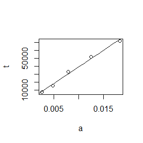

```r
n=c(1e3,2e3,4e3,6e3,8e3)
a=c(t1,t2,t3,t4,t5)
t=n*log(n)
b0=lm(t~a)$coefficients[1]
b1=lm(t~a)$coefficients[2]
plot(a,t)
x<-seq(0, 0.25, 0.001)
lines(x,b0+b1*x)
```

The figure shows that the regression line fit well with the scatter.So we can consider that the relationship between t and n maybe nlog(n) with something translation and scaling transformation.

## Question 2

In Example 5.7 the control variate approach was illustrated for Monte Carlo integration of
$$θ =
\int_{0}^{1} e^xdx$$
. Now consider the antithetic variate approach. Compute $Cov(e^U , e^{1−U} )$ and $Var(e^U + e^{1−U} )$, where U ∼ Uniform(0,1). What is the percent reduction in variance of $\hat{θ}$ that can be achieved using antithetic variates (compared with simple MC)?

## Answer 2

We can calculate as follows ：

For U~U(0,1)

$E(e^U)=E(e^{1-U})=\int_{0}^{1} e^xdx=e-1$

$E(e^{2U})=E(e^{2(1-U)})=\int_{0}^{1} e^{2x}dx=\frac{e^2-1}{2}$

$Var(e^U)=Var(e^{1-U})=E(e^{2U})-(E(e^U))^2=\frac{e^2-1}{2}-(e-1)^2=0.2420356$

So
$$Cov(e^U ,
e^{1−U})=E(e^Ue^{1-U})-E(e^U)E(e^{1-U})=e-(e-1)^2=-0.2342106$$

$$Var(e^U + e^{1−U}
)=Var(e^U)+Var(e^{1-U})+2Cov(e^U , e^{1−U})=0.01564999$$
Then we assume $\hat{\theta}=\frac{e^U + e^{V}}{2}$ ,and U 、V are independent.

$$Var(\hat{\theta})=Var(e^U)/2=\frac{e^2-1}{4}-\frac{(e-1)^2}{2}=0.1210178$$
Then use the antithetic variate $\hat{\theta}_{an}=\frac{e^U + e^{1-U}}{2}$

$$Var(\hat{\theta}_{an})=Var(e^U +
e^{1−U})/4=0.003912497$$
So the percent of reduction:

$$\frac{Var(\hat{\theta})-Var(\hat{\theta}_{an})}{Var(\hat{\theta})}=0.9676701$$

## Question 3

Refer to Exercise 5.6. Use a Monte Carlo simulation to estimate θ by the antithetic variate approach and by the simple Monte Carlo method. Compute an empirical estimate of the percent reduction in variance using the antithetic variate. Compare the result with the theoretical value from Exercise 5.6.

## Answer 3

```r
set.seed(1234)
n=1000
u1=runif(n)
u2=runif(n)
u3=1-u1
t1=(mean(exp(u1))+mean(exp(u2)))/2
t2=(mean(exp(u1))+mean(exp(u3)))/2
se1=sd((exp(u1)+exp(u2))/2)
se2=sd((exp(u1)+exp(u3))/2)
p=(se1^2-se2^2)/se1^2
p
```

```
## [1] 0.9662576
```

###A-22001-2022-09-30

## Exercise 5.13

Find two importance functions $f_1$ and $f_2$ that are supported on $(1, ∞)$ and are ‘close’ to

$$g(x) =\frac{x^2}{\sqrt{2\pi}}e^{−x^{2}/2}, x>1.$$
Which of your two importance functions should produce the smaller variance in estimating

$$\int_{1}^{\infty} \frac{x^2}{\sqrt{2\pi} }e^{−x^2/2}dx$$
by importance sampling? Explain.

**Solution.**

·Find two importance functions $f_1$ and $f_2$ that are supported on $(1, ∞)$ and are ‘close’ to g(x).

Here we can consider $f_1$、$f_2$ follows some truncated Normal distribution and shifted F distribution which are supported on x > 1.

So we choose
$$f_1(x)=\frac{e^{−(x-1)^2/2}}{\sqrt{2\pi}
}/\int_{1}^{\infty}\frac{e^{−(x-1)^2/2}}{\sqrt{2\pi}
}=2\frac{e^{−(x-1)^2/2}}{\sqrt{2\pi} } ,x>1.$$
It means we have a truncated Normal distribution ,i.e. $X_1$~$N(1,1)$ on $x_1>1$.

Both are satisfied the conditions that the support set is (1, ∞).

We graph g(x)、$f_1$ and $f_2$ so that we can compare them directly.

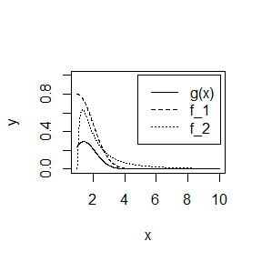

```r
 x <- seq(1, 10, 0.01)
 y <- x^2 * exp(-x^2/2)/sqrt(2 * pi)
 plot(x, y, type = "l", ylim = c(0, 1))
 lines(x, 2*dnorm(x, 1,1), lty = 2)#Truncated Normal distribution
 lines(x, df(x - 1, 4, 4), lty = 3)#shifted F distribution
 legend("topright", inset = 0.03, legend = c("g(x)", "f_1",
  "f_2"), lty = 1:3)
```

As is shown above, $f_1$ and $f_2$ seem both are ‘close’ to g(x).

Because variance of importance sampling $\hat{θ}$ is $var(g(X_1)/f (X_1))/m$, which has the minimal value 0 when g(·) = cf (·) for some constant c.

Then Compare the ratios g(x)/f(x).The plot showed as follows:

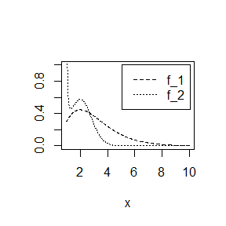

```r
plot(x, y/(2*dnorm(x, 1,1)), type = "l", lty = 2,
 ylab = "",ylim = c(0, 1))
 lines(x, y/df(x - 1, 4, 4), lty = 3)
 legend("topright", inset = 0.03, legend = c("f_1", "f_2"),
 lty = 2:3)
```

The plot shows that the ratio g(x)/f(x) of truncated normal importance function is closer to a constant function than the shifted F distribution . So we may consider the truncated normal importance function as it can produce the smaller variance in estimating the integral .

## Exercise 5.15

Obtain the stratified importance sampling estimate in Example 5.13 and compare it with the result of Example 5.10.

*Example 5.13 (Example 5.10, cont.)*

In Example 5.10 our best result was obtained with importance function $f_3(x) =e^{−x}/(1 − e^{−1}), 0 <x< 1.$ From 10000 replicates we obtained the estimate $\hat{θ}$ = 0.5257801 and an estimated standard error 0.0970314.

Now divide the interval (0,1) into five subintervals, (j/5,(j + 1)/5), j = 0, 1,…, 4. Then on the jth subinterval variables are generated from the density
$$f_{j}(x)=\frac{5e^{−x}}{ 1 − e^{−1}} , \frac{j −
1}{ 5} <x< \frac{j}{5}.$$
(There is something wrong with this subintervals.) So we just modify it’s subintervals slightly as follows:

$$f_{j}(x)=\frac{5e^{−x}}{ 1 − e^{−1}} ,
a_{j-1} <x< a_{j}.$$
Where $a_j=F^{-1}(\frac{j}{k})$

$$F(x)=\int_{0}^{x}f(x)dx=\frac{1-e^{-x}}{1-e^{-1}}$$

Then
$$a_{j}=F^{-1}(\frac{j}{k})=-log(1-\frac{j}{k}(1-e^{-1}))$$
**Solution.**

Our aim is to estimate $\int _{0}^{1} e^{−t}/(1 + t^2)dt$.

The integration with simple importance sampling can be written as:
$$\begin{aligned}
\int_0^1 e^{−t}/(1 + t^2)dt& =
\sum\limits_{i=1}^{k}\int_{(i-1)/k}^{i/k}e^{−t}/(1 + t^2)dt\\
&=\frac{1}{k} \sum\limits_{i=1}^{k}\int_{(i-1)/k}^{i/k}ke^{−t}/(1 +
t^2)dt\\
&= \frac{1}{k}\sum\limits_{i=1}^{k}E(e^{−X_{i}}/(1 + X_{i}^2)) \\
&=\frac{1}{k}\sum\limits_{i=1}^{k}E(g_{i}(X))\\
where X ∼ U((i − 1)/k, i/k).
\end{aligned}$$
with importance function
$$f(x) =
e^{−x}/( 1 − e^{−1}) , 0 <x< 1,$$
on five subintervals, (a_{j-1} , a_{j}), j = 0, 1,…, 4. On the jth subinterval
$$f_{j}(x)=\frac{5e^{−x}}{ 1 − e^{−1}} , a_{j-1}
<x< a_{j}.$$

Where
$$a_{j}=F^{-1}(\frac{j}{k})=-log(1-\frac{j}{k}(1-e^{-1}))$$
Then we have the stratified inportance sampling:

$$\begin{aligned}
\int_0^1 e^{−t}/(1 + t^2)dt
&=\frac{1}{k}\sum\limits_{i=1}^{k}E(g_{i}(X))\\
&=\frac{1}{k}\sum\limits_{i=1}^{k}E(g_{i}(X)/f_{i}(x))\\
where X ∼ f_{i}(x).
\end{aligned}$$

```r
set.seed(1234)
 n <- 1000
 k <- 5
 m <- n/k
 t <- numeric(k)
 va <- numeric(k)
 g <- function(x) exp(-x)/(1 + x^2)
 f <- function(x) k*(1/(1 - exp(-1))) * exp(-x)
 for (j in 1:k) {
 u <- runif(m, (j-1)/k, j/k)
 x<--log(1-(1-exp(-1))*u)
 gf <- g(x)/f(x)
 t[j] <- mean(gf)
 va[j] <- var(gf)
 }
```

```r
sum(t)
```

```
## [1] 0.5242093
```

```r
mean(va)
```

```
## [1] 1.836155e-05
```

Without stratification :

```r
set.seed(234)
 n <- 1000
 k <- 1
 m <- n/k
 t <- numeric(k)
 va <- numeric(k)
 g <- function(x) exp(-x)/(1 + x^2)
 f <- function(x) (1/(exp(-(j-1)/k) - exp(-j/k))) * exp(-x)
 for (j in 1:k) {
 u <- runif(m, (j - 1)/k, j/k)
 x <- -log(exp(-(j-1)/k) - ((exp(-(j-1)/k) - exp(-j/k))) * u)#the inverse transform method
 gf <- g(x)/f(x)
 t[j] <- mean(gf)
 va[j] <- var(gf)
 }
```

```r
sum(t)
```

```
## [1] 0.5290944
```

```r
mean(va)
```

```
## [1] 0.008792394
```

###A-22001-2022-10-09

### Exercise 6.4

Suppose that $X_1,...,X_n$ are a random sample from a from a lognormal distribution with unknown parameters. Construct a 95% confidence interval for the parameter µ. Use a Monte Carlo method to obtain an empirical estimate of the confidence level.

**Solution.**

Since $X_1,...,X_n$ are a random sample from a from a lognormal distributiony.

We have $X=e^{Y}$~$LN(\mu,\sigma^{2})$,where $Y$~$N(\mu,\sigma^2)$.

so we can construct the confidence interval for the parameter µ follow these steps:

1.Generate random sample $X_1,...,X_n$ following lognormal distributiony

2.Calculate $Y_1,...,Y_n$,where $Y_i=log(X_i)$and $Y_i$~$N(\mu,\sigma^2)$.

3.Use Y and normal distribution to construct the confidence interval for the parameter µ :

$$[\bar{Y}-\sqrt{\frac{se^{2}}{n}}z_{\alpha/2},\bar{Y}+\sqrt{\frac{se^{2}}{n}}z_{\alpha/2}]$$

4.Repeat m times ,we can obtain an empirical estimate of the confidence level.

We assume $\mu=0$,$\sigma^2=1$,then the code can be written as follows:

```r
set.seed(123)
n<-100
m<-1000
x<-numeric(n)
y<-numeric(n)
CIL<-numeric(m)
CIU<-numeric(m)
i=1
for (i in 1:m)
{
  x=rlnorm(n)
  y=log(x)
  ybar=mean(y)
  se=sd(y)
  s=se/sqrt(n)
  CIL[i]=ybar+s*qnorm(0.025)
  CIU[i]=ybar+s*qnorm(0.975)
  i=i+1
}
```

```r
mean(0>=CIL & 0<=CIU)
```

```
## [1] 0.965
```

This result is very close to 0.95.

### Exercise 6.8

Refer to Example 6.16. Repeat the simulation, but also compute the F test of equal variance, at significance level $\hat{α}$ . = 0.055. Compare the power of the Count Five test and F test for small, medium, and large sample sizes. (Recall that the F test is not applicable for non-normal distributions.)

*Example 6.16*

Example 6.16 (Count Five, cont.) Use Monte Carlo methods to estimate the power of the Count Five test, where the sampled distributions are $N(µ_1 = 0, σ^{2}_1 = 1)$, $N(µ_2 = 0, σ^2_2 = 1.52)$, and the sample sizes are $n_1 = n_2 = 20$.

```r
count5test <- function(x, y) {
X <- x - mean(x)
Y <- y - mean(y)
outx <- sum(X > max(Y)) + sum(X < min(Y))
outy <- sum(Y > max(X)) + sum(Y < min(X))
# return 1 (reject) or 0 (do not reject H0)
return(as.integer(max(c(outx, outy)) > 5))
}
#generate samples under H1 to estimate power
m <- 1000
sigma1 <- 1
sigma2 <- 1.5
power <- mean(replicate(m, expr={
x <- rnorm(20, 0, sigma1)
y <- rnorm(20, 0, sigma2)
count5test(x, y)
}))
```

```r
print(power)
```

```
## [1] 0.32
```

**Solution.**

We need to Compare the power of the Count Five test and F test for small, medium, and large sample sizes. (Recall that the F test is not applicable for non-normal distributions.)

So we choose different n=20,50,100,500,1000 for comparing.

```r
count5test <- function(x, y) {
X <- x - mean(x)
Y <- y - mean(y)
outx <- sum(X > max(Y)) + sum(X < min(Y))
outy <- sum(Y > max(X)) + sum(Y < min(X))
# return 1 (reject) or 0 (do not reject H0)
return(as.integer(max(c(outx, outy)) > 5))
}
#generate samples under H1 to estimate power
sigma1 <- 1
sigma2 <- 1.5
```

The code of Count Five test:

```r
m <- 1000
sigma1 <- 1
sigma2 <- 1.5
c5<-numeric(5)
i=1
for (n in c(20,50,100,500,1000)){
 power <- mean(replicate(m, expr={
 x <- rnorm(n, 0, sigma1)
 y <- rnorm(n, 0, sigma2)
 count5test(x, y)
 }))
  print(power)
 }
```

```
## [1] 0.32
## [1] 0.687
## [1] 0.841
## [1] 0.993
## [1] 0.999
```

The code of F test:

```r
m <- 1000
sigma1 <- 1
sigma2 <- 1.5
c5<-numeric(5)
i=1
for (n in c(20,50,100,500,1000)){
 Ftest <- mean(replicate(m, expr={
 x <- rnorm(n, 0, sigma1)
 y <- rnorm(n, 0, sigma2)
 Fp <- var.test(x, y)$p.value
 f <- as.integer(Fp <= 0.055)
 }))
  print(Ftest)
  }
```

```
## [1] 0.439
## [1] 0.819
## [1] 0.975
## [1] 1
## [1] 1
```

It can be seen that the F-test for equal variance is more powerful as it’s power is higher than the Count Five test in each cases of different sample sizes. And for the F-test ,the power is approching 1 more quickly.

### Discussion

If we obtain the powers for two methods under a particular simulation setting with 10,000 experiments: say, 0.651 for one method and 0.676 for another method. Can we say the powers are different at 0.05 level?

• What is the corresponding hypothesis test problem?

• Which test can we use? Z-test, two-sample t-test, paired-t test or McNemar test? Why?

• Please provide the least necessary information for hypothesis testing.

**Solution.** •We Conside the hypothesis test problem:

$$H_0:p_1=p_2 \leftrightarrow H_1:p_1\neq
p_2$$
•We may consider Z-test and McNemar test.

For the Z-test:we consider each experiments are independent ,so the normal approximation could be chosen.

For the McNemar test: it’s a nonparamatric methods in the homogeneity test when we have no more information about the distribution.

• We consider the Z-test first:

For
$$n_1\bar{X}\sim
B(n_1,p_1),n_2\bar{Y}\sim B(n_2,p_2)$$

Consider the large sample approximation, we have:

$$\bar{X}\sim
(p_1,\frac{p_1(1-p_1)}{n_1}),\bar{Y}\sim
(p_2,\frac{p_2(1-p_2)}{n_2})$$

Under the null hypothesis, we have $p_1=p_2=p$

And we use the frequency $\hat{p}=\frac{n_1\bar{X}+n_2\bar{Y}}{n_1+n_2}$

then when the sample large enough:

$$U=\frac{\bar{X}-\bar{Y}}{\sqrt{\hat{p}(1-\hat{p})}\sqrt{\frac{1}{n_1}+\frac{1}{n_2}}}\sim
N(0,1)$$
Then since this question $n_1=n_2=10000$,$\bar{X}=0.651$,$\bar{Y}=0.676$,$\hat{p}=(651+676)/20000=0.6635$

Caculate u:

$$u=\frac{0.676-0.651}{\sqrt(0.6635(1-0.6635))\sqrt{2/10000}}$$

```r
u=(0.676-0.651)/sqrt((0.6635*(1-0.6635)))/sqrt(2/10000)
u
```

```
## [1] 3.741209
```

since $\alpha=0.05$,$u_{\alpha/2}=1.96$,$u=3.74>1.96$,so we may reject the null hypothesis,and consider $p_1\neq p_2$

Then consider the McNemar test:

It can be seen that the contingency table is not complete ,so we simulate the result to construct the test statistics:

$$T=\frac{(x_2-y_1)^2}{(x_2+y_1)}\sim_{H_0}\mathcal{X}(1)$$
we couldn’t calculate $x_2$,$y_1$ in this problem,we just have the equation：

$$x_1+x_2=676$$
$$x_1+y_1=651$$
then we just simulate the result:

since $\mathcal{X}_{0.05}(1)=3.84$

```r
set.seed(123)
x1=sample(0:651,100000,replace=TRUE)
x2=676-x1
y1=651-x1
z=(x2-y1)^2/(x2+y1)
mean(z)#<3.84
```

```
## [1] 1.924013
```

```r
mean(z>3.84)
```

```
## [1] 0.10546
```

the result is not reject the null hypothesis by this method,we may consider $p_1=p_2$.

It can be found that differnt methods make differnet results .But in my opinion ,I think the Z-test may be more suitable for this problem ,because the infomation for Z-test is quite complete while we may choose simulation in McNemar test, it may result in something wrong.  
###A-22001-2022-10-14

### Exercise 7.4

Refer to the air-conditioning data set aircondit provided in the boot package. The 12 observations are the times in hours between failures of airconditioning equipment [63, Example 1.1]:

3, 5, 7, 18, 43, 85, 91, 98, 100, 130, 230, 487.

Assume that the times between failures follow an exponential model Exp(λ). Obtain the MLE of the hazard rate λ and use bootstrap to estimate the bias and standard error of the estimate.

**Solution.**

Since $X_1,...,X_12$ are follow an exponential model Exp(λ).

We use MLE to obtain $\lambda$,the likelihood function:

$$L(\lambda)=\lambda^{n}e^{-\sum_{i=1}^nX_i\lambda}$$

the logarithmic likelihood function：

$$l(\lambda)=nlog\lambda-\sum_{i=1}^nX_i\lambda$$

$$\frac{dl(\lambda)}{d\lambda}=\frac{n}{\lambda}-\sum_{i=1}^nX_i=0$$
Obtain the MLE of $\lambda$:

$$\hat{\lambda}=\frac{n}{\sum_{i=1}^nX_i}=\frac{1}{\bar{X}}$$

Then we use bootstrap to estimate the bias and standard error of the estimate.The code and result are shown as follow:

```r
library(boot)
x=c(3, 5, 7, 18, 43, 85, 91, 98, 100, 130, 230, 487)
lambda=1/mean(x);
B <- 1e4; set.seed(12345);lambdastar <- numeric(B)
for(b in 1:B){
xstar <- sample(x,replace=TRUE)
lambdastar[b] <- 1/mean(xstar)
}
lambda#original statistic
```

```
## [1] 0.00925212
```

```r
mean(lambdastar)-lambda# the bias
```

```
## [1] 0.00131529
```

```r
sd(lambdastar)#bootstrap standard error
```

```
## [1] 0.004292739
```

### Exercise 7.5

Refer to Exercise 7.4. Compute 95% bootstrap confidence intervals for the mean time between failures 1/λ by the standard normal, basic, percentile, and BCa methods. Compare the intervals and explain why they may differ.

**Solution.**

For the estimate of $\frac{1}{\lambda}$:

$$\hat{\theta}=\frac{1}{\hat{\lambda}}=\bar{x}$$

We can use the R-package ‘boot’ to calculate the confidence intervals by the standard normal, basic, percentile, and BCa methods;the result shows as follows:

```r
library(boot)
x=c(3, 5, 7, 18, 43, 85, 91, 98, 100, 130, 230, 487)
set.seed(12345)
boot.mean <- function(x,i) mean(x[i])
r <- boot(x, statistic = boot.mean, R = 3000)
r
```

```
##
## ORDINARY NONPARAMETRIC BOOTSTRAP
##
##
## Call:
## boot(data = x, statistic = boot.mean, R = 3000)
##
##
## Bootstrap Statistics :
##     original      bias    std. error
## t1* 108.0833 -0.06394444    38.21252
```

```r
boot.ci(r, type = c("norm", "perc", "basic", "bca"))
```

```
## BOOTSTRAP CONFIDENCE INTERVAL CALCULATIONS
## Based on 3000 bootstrap replicates
##
## CALL :
## boot.ci(boot.out = r, type = c("norm", "perc", "basic", "bca"))
##
## Intervals :
## Level      Normal              Basic
## 95%   ( 33.3, 183.0 )   ( 23.6, 171.7 )
##
## Level     Percentile            BCa
## 95%   ( 44.4, 192.6 )   ( 55.9, 226.4 )
## Calculations and Intervals on Original Scale
```

We can also graph the histogram of $\hat{\theta}$:

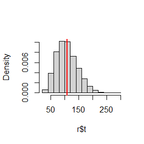

```r
hist(r$t, prob = TRUE, main = "")
abline(v=r$t0,col='red',lwd=2)
```

It can be noted that the 95% confidence interval: Normal method is ( 33.3, 183.0 ); Basic method is ( 23.6, 171.7 ) ;Percentile method is ( 44.4, 192.6 ) ;BCa method is ( 55.9, 226.4 )

The histogram are showed that $\hat{\theta}$ may not approximately normal , so the normal and percentile intervals differ. And the histogram also has displayed that it’s a right-skewed distribution, so we just use a small size sample that we could not give a good approximation when we choose CLT .

### Exercise 7.A

Conduct a Monte Carlo study to estimate the coverage probabilities of the standard normal bootstrap confidence interval, the basic bootstrap confidence interval, and the percentile confidence interval. Sample from a normal population and check the empirical coverage rates for the sample mean. Find the proportion of times that the confidence intervals miss on the left, and the porportion of times that the confidence intervals miss on the right.

**Solution.**

```r
mu<-0;b<-1;n<-500;m<-1e3;library(boot);set.seed(435)
boot.mean <- function(x,i) mean(x[i])
ci.norm<-ci.basic<-ci.perc<-matrix(NA,m,2)
for(i in 1:m){
R<-rnorm(n,0,1);
de <- boot(data=R,statistic=boot.mean, R = 1000)
ci <- boot.ci(de,type=c("norm","basic","perc"))
ci.norm[i,]<-ci$norm[2:3];ci.basic[i,]<-ci$basic[4:5]
ci.perc[i,]<-ci$percent[4:5];
}
```

The standard normal bootstrap confidence interval:

$$( \hat{ θ} − z_{1−α/2} \hat{ se}( \hat
θ), \hatθ − z_{α/2} \hat{ se}( \hat θ))$$
so we can calculate the empirical coverage rates:

```r
mean(ci.norm[,1]<=mu & ci.norm[,2]>=mu)
```

```
## [1] 0.956
```

the basic bootstrap confidence interval： The (1 − α)-CI of θ is：

$$( \hatθ − F^{−1} (1 − α/2), \hat θ −
F^{−1} (α/2))$$
$F^{−1} (1 − α/2)$ and $F^{ −1} (α/2)$ can be approximated by the (1 − α/2)- and (α/2)-quantiles of $\hatθ ^{∗} − \hat θ$:$\hatθ^{∗}_{1−α/2} −\hatθ$ and$\hatθ^{∗}_{α/2} −\hatθ$:

The resulting (1 − α)-CI is

$$(2 \hatθ − \hat{θ}^{∗}_{1−α/2} ,2 \hatθ
− \hatθ^{∗}_{α/2} )$$
the empirical coverage rates：

```r
mean(ci.basic[,1]<=mu & ci.basic[,2]>=mu)
```

```
## [1] 0.954
```

The percentile confidence interval:
$$(
\hat θ^{*}_{α/2} ,\hatθ^∗_{1−α/2} )$$
the empirical coverage rates：

```r
mean(ci.perc[,1]<=mu & ci.perc[,2]>=mu)
```

```
## [1] 0.955
```

###A-22001-2022-10-21

### Exercise 7.8

Refer to Exercise 7.7. Obtain the jackknife estimates of bias and standard error of $\hatθ$.

**Exercise 7.7**

Refer to Exercise 7.6. Efron and Tibshirani discuss the following example [84, Ch. 7]. The five-dimensional scores data have a 5 × 5 covariance matrix Σ, with positive eigenvalues $λ_1 > ··· > λ_5$. In principal components analysis,
$$θ =
\frac{\lambda_{1}}{\sum\limits_{i=1}^{5}\lambda_{i}}$$
measures the proportion of variance explained by the first principal component. Let $\hatλ_1 > ··· > \hatλ_5$ be the eigenvalues of $\hatΣ$, where ˆ Σ is the MLE of Σ. Compute the sample estimate
$$\hatθ =
\frac{\hat\lambda_{1}}{\sum\limits_{i=1}^{5}\hat\lambda_{i}}$$

**Solution.**

Then we use jackknife to estimate the bias and standard error of the estimate.The code and result are shown as follow:

```r
set.seed(123)
 library(bootstrap)
 s <- as.matrix(scor)
 n <- nrow(s)
 theta <- rep(0,n)
 m=cov(s)
 lambda <- eigen(m)$values
 theta.hat <- max(lambda)/sum(lambda)
 for (i in 1:n) {
 y <- s[-i, ]
 x <- cov(y)
 lambda <- eigen(x)$values
 theta[i] <- max(lambda)/sum(lambda)
 }
 bias <- (n - 1) * (mean(theta) - theta.hat)
 se <- sqrt((n - 1) * mean((theta - mean(theta))^2))

 bias
```

```
## [1] 0.001069139
```

```r
 se
```

```
## [1] 0.04955231
```

So it can be noted that we use jackknife to estimate the bias 0.001069139,standard error is 0.04955231.

### Exercise 7.11

In Example 7.18, leave-one-out (n-fold) cross validation was used to select the best fitting model. Use leave-two-out cross validation to compare the models.

**Solution.** We choose leave-two-out cross validation to select the best fitting model from:

$$Linear: Y = β_0 + β_1 X +
\epsilon$$

$$Quadratic: Y = β_0 + β_1 X + β_2 X^2 +
\epsilon$$

$$Exponential: log(Y) = β_ 0 + β_1 X +
\epsilon$$

$$Log-log: log(Y) = β_0 + β_1 log(X) +
\epsilon$$

Comparing the leave-two-out cross validation with leave-one-out cross validation, the leave-two-out method shown as follows

```r
library(DAAG, warn.conflict = FALSE)
 attach(ironslag)
 n <- length(chemical)
 N <- choose(n, 2)
 e1 <-  numeric(N)
 m <- 1
 for (i in 1:(n - 1))
    for (j in (i + 1):n)
      {
       k <- c(i, j)
       y <- magnetic[-k]
       x <- chemical[-k]
       M1 <- lm(y ~ x)
       y.h1 <- M1$coef[1] + M1$coef[2] * chemical[k]
       e1[m] <- sum((magnetic[k] - y.h1)^2)
       m=m+1
 }
 mean(e1)
```

```
## [1] 39.14455
```

```r
 n <- length(chemical)
 N <- choose(n, 2)
 e2 <-  numeric(N)
 m <- 1
 for (i in 1:(n - 1))
   for (j in (i + 1):n)
     {
      k <- c(i, j)
      y <- magnetic[-k]
      x <- chemical[-k]
      M2 <- lm(y ~ x + I(x^2))
      y.h2 <- M2$coef[1] + M2$coef[2] * chemical[k] +
      M2$coef[3] * chemical[k]^2
      e2[m] <- sum((magnetic[k] - y.h2)^2)
      m=m+1
 }
 mean(e2)
```

```
## [1] 35.74037
```

```r
 n <- length(chemical)
 N <- choose(n, 2)
 e3 <-  numeric(N)
 m <- 1
 for (i in 1:(n - 1))
   for (j in (i + 1):n)
     {
       k <- c(i, j)
       y <- magnetic[-k]
       x <- chemical[-k]
       M3 <- lm(log(y) ~ x)
       logy.h3 <- M3$coef[1] + M3$coef[2] * chemical[k]
       y.h3 <- exp(logy.h3)
       e3[m] <- sum((magnetic[k] - y.h3)^2)
       m=m+1
 }
 mean(e3)
```

```
## [1] 36.90983
```

```r
 n <- length(chemical)
 N <- choose(n, 2)
 e4 <-  numeric(N)
 m <- 1
 for (i in 1:(n - 1))
   for (j in (i + 1):n)
     {
       k <- c(i, j)
       y <- magnetic[-k]
       x <- chemical[-k]
       M4 <- lm(log(y) ~ log(x))
       logy.h4 <- M4$coef[1] + M4$coef[2]*log(chemical[k])
       y.h4 <- exp(logy.h4)
       e4[m] <- sum((magnetic[k] - y.h4)^2)
       m=m+1
 }
 mean(e4)
```

```
## [1] 40.93436
```

in example 7.18 we use leave-one-out (n-fold) cross validation ,which has calculated the average squared prediction error:$e_1=19.6,e_2=17.9,e_3=18.4,e_4=20.4$So,we choose the Quadratic Model ,as it’s average squared prediction error is smallest

Then we use leave-two-out (n-fold) cross validation to calculated the average squared prediction error:$e_1=39.14455,e_2=35.74037,e_3=36.90983,e_4=40.93436$So,we choose the Quadratic Model too ,as it also has a smallest average squared prediction error.

### Exercise 8.2

Implement the bivariate Spearman rank correlation test for independence [255] as a permutation test. The Spearman rank correlation test statistic can be obtained from function cor with method = “spearman”. Compare the achieved significance level of the permutation test with the p-value reported by cor.test on the same samples.

**Solution.**

```r
p.spear<-function(x,y)
{
  test<-cor.test(x,y,method='spearman')
  n=length(x)
  retest<-replicate(R, expr = {
                               k <- sample(1:n)
                               cor.test(x[k], y, method =                                "spearman")$estimate
                                })
  b <- c(test$estimate, retest)
  p <- mean(as.integer(test$estimate <=
    b))
  return(list(rho.s = test$estimate, p.value = p))
}
```

Then we may compare the achieved significance level of the permutation test with the p-value reported by cor.test on the same samples from the Multinormal distribution,where the true $corr(X_1,X_2)=0.6$

```r
set.seed(123)
library(MASS)
 mu <- c(0, 0)
 Sigma <- matrix(c(1, 0.6, 0.6, 1), 2, 2)
 n <- 50
 R <- 500
 x <- mvrnorm(n, mu, Sigma)
```

```r
cor.test(x[, 1], x[, 2], method = "spearman")
```

```
##
##  Spearman's rank correlation rho
##
## data:  x[, 1] and x[, 2]
## S = 8704, p-value = 1.368e-05
## alternative hypothesis: true rho is not equal to 0
## sample estimates:
##       rho
## 0.5820408
```

```r
p.spear(x[, 1], x[, 2])
```

```
## $rho.s
##       rho
## 0.5820408
##
## $p.value
## [1] 0.001996008
```

###A-22001-2022-10-28

### Exercise 9.4

Implement a random walk Metropolis sampler for generating the standard Laplace distribution (see Exercise 3.2). For the increment, simulate from a normal distribution. Compare the chains generated when different variances are used for the proposal distribution. Also, compute the acceptance rates of each chain.

Then use the Gelman-Rubin method to monitor convergence of the chain, and run the chain until it converges approximately to the target distribution according to $\hat{R} < 1.2$.

**Solution.** The standard Laplace distribution has density
$$f(x) = \frac{1}{2} e^{−|x|}, x ∈
R$$

The proposal distribution follows $N(\mu,\sigma^2)$

For the Metropolis sampler: g(r|s) = g(s|r) so that,
$$α(r,s) = min \{f (s)/f
(r),1\}=min\{e^{|r|-|s|},1\}$$

Generating the standard Laplace distribution:

```r
    set.seed(1234)
    f<-function(x){
      d=1/2*exp(-abs(x))
      return(d)
    }

    rw.Metropolis <- function(n, sigma, x0, N) {
        x <- numeric(N)
        x[1] <- x0
        u <- runif(N)
        k <- 0
        for (i in 2:N) {
            y <- rnorm(1, x[i-1], sigma)
                if (u[i] <= (f(y) / f(x[i-1])))
                    x[i] <- y
                else {
                    x[i] <- x[i-1]
                    k <- k + 1
                }
            }
        return(list(x=x, k=k))
    }

    n <- 4  #degrees of freedom for target Student t dist.
    N <- 5000
    sigma <- c( .5,1,3,5)

    x0 <- 25
    rw1 <- rw.Metropolis(n, sigma[1], x0, N)
    rw2 <- rw.Metropolis(n, sigma[2], x0, N)
    rw3 <- rw.Metropolis(n, sigma[3], x0, N)
    rw4 <- rw.Metropolis(n, sigma[4], x0, N)
```

the Gelman-Rubin method:

```r
Gelman.Rubin <- function(psi) {
        # psi[i,j] is the statistic psi(X[i,1:j])
        # for chain in i-th row of X
        psi <- as.matrix(psi)
        n <- ncol(psi)
        k <- nrow(psi)

        psi.means <- rowMeans(psi)     #row means
        B <- n * var(psi.means)        #between variance est.
        psi.w <- apply(psi, 1, "var")  #within variances
        W <- mean(psi.w)               #within est.
        v.hat <- W*(n-1)/n + (B/n)     #upper variance est.
        r.hat <- v.hat / W             #G-R statistic
        return(r.hat)
        }
```

Use the Gelman-Rubin method to monitor convergence of the chain:

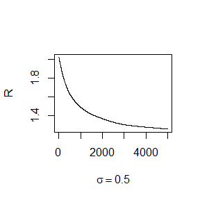

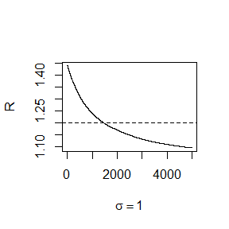

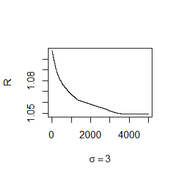

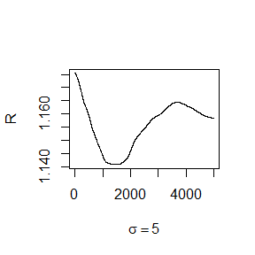

```r
s <- c(0.5,1,3,5)     #parameter of proposal distribution
    n <- 4          #number of chains to generate
    N <- 6000     #length of chains
    b <- 1000       #burn-in length

    #choose overdispersed initial values
    x0 <- c(-10, -5, 5, 10)
set.seed(12345)
for(k in 1:n){
    X <- matrix(0, nrow=n, ncol=N)
    for (i in 1:n)
        X[i,] <- rw.Metropolis(n,s[k],x0[i],N)$x
   psi <- t(apply(X, 1, cumsum))
    for (i in 1:nrow(psi))
        psi[i,] <- psi[i,] / (1:ncol(psi))
      #plot the sequence of R-hat statistics
    rhat <- rep(0, N)
    for (j in (b+1):N)
        rhat[j] <- Gelman.Rubin(psi[,1:j])
    plot(rhat[(b+1):N], type="l", xlab=bquote(sigma == .(round(s[k],3))), ylab="R")
    abline(h=1.2, lty=2)
}
```

```r
s <- c(0.5,1,3,5)     #parameter of proposal distribution
    n <- 4          #number of chains to generate
    N <- 6000      #length of chains
    b <- 1000       #burn-in length
   par(mfrow=c(2,2))
    x0 <- 10
set.seed(12345)
rw1 <- rw.Metropolis(n, s[1], x0, N)
    rw2 <- rw.Metropolis(n, s[2], x0, N)
    rw3 <- rw.Metropolis(n, s[3], x0, N)
    rw4 <- rw.Metropolis(n, s[4], x0, N)
    refline <- qt(c(.025, .975), df=n)
    rw <- cbind(rw1$x, rw2$x, rw3$x,  rw4$x)
```

### Exercise 9.7

Implement a Gibbs sampler to generate a bivariate normal chain $(X_t, Y_t)$ with zero means, unit standard deviations, and correlation 0.9. Plot the generated sample after discarding a suitable burn-in sample. Fit a simple linear regression model $Y = β_0 + β_1X$ to the sample and check the residuals of the model for normality and constant variance.

Then use the Gelman-Rubin method to monitor convergence of the chain, and run the chain until it converges approximately to the target distribution according to $\hat{R} < 1.2$.

**Solution.**

```r
N <- 5000 #length of chain
burn <- 1000 #burn-in length
X <- matrix(0, N, 2) #the chain, a bivariate sample
rho <- .9 #correlation
mu1 <- 0
mu2 <- 0
sigma1 <- 1
sigma2 <- 1
x01<-mu1 #initialize
x02<-mu2
###### generate the chain #####
NG<-function(N,mu1,mu2,sigma1,sigma2,rho,x01,x02){
  s1 <- sqrt(1-rho^2)*sigma1
  s2 <- sqrt(1-rho^2)*sigma2
  X[1,]<c(x01,x02)
    for (i in 2:N) {
                    x2 <- X[i-1, 2]
                    m1 <- mu1 + rho * (x2 - mu2) * sigma1/sigma2
                    X[i, 1] <- rnorm(1, m1, s1)
                    x1 <- X[i, 1]
                    m2 <- mu2 + rho * (x1 - mu1) * sigma2/sigma1
                    X[i, 2] <- rnorm(1, m2, s2)
    }
  X1<-X[,1]
X2<-X[,2]
return(list(X1=X1,Y1=X2))
}
```

Generated sample after discarding a suitable burn-in which we choose b=1000,then plot the burn-in sample:

```r
b <- burn + 1
x<-NG(N,mu1,mu2,sigma1,sigma2,rho,x01,x02)$X1
y<-NG(N,mu1,mu2,sigma1,sigma2,rho,x01,x02)$Y1
X<-x[b:N]
Y<-y[b:N]
```

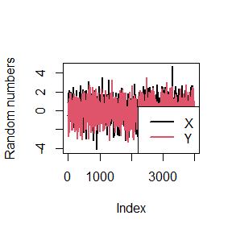

```r
plot(X,type='l',col=1,lwd=2,xlab='Index',ylab='Random numbers')
lines(Y,col=2,lwd=2)
legend('bottomright',c(expression(X),expression(Y)),col=1:2,lwd=2)
```

Fit a simple linear regression model $Y = β_0 + β_1X$ to the sample:

```r
l=lm(Y~X)
summary(lm(Y~X))
```

```
##
## Call:
## lm(formula = Y ~ X)
##
## Residuals:
##     Min      1Q  Median      3Q     Max
## -3.4764 -0.7157  0.0182  0.6934  3.6909
##
## Coefficients:
##             Estimate Std. Error t value Pr(>|t|)
## (Intercept) -0.09737    0.01597  -6.097 1.18e-09 ***
## X            0.05525    0.01532   3.605 0.000315 ***
## ---
## Signif. codes:  0 '***' 0.001 '**' 0.01 '*' 0.05 '.' 0.1 ' ' 1
##
## Residual standard error: 1.006 on 3998 degrees of freedom
## Multiple R-squared:  0.003241,   Adjusted R-squared:  0.002991
## F-statistic:    13 on 1 and 3998 DF,  p-value: 0.0003155
```

The qq plot of the residual of the generated chain (after discarding the burn-in sample) is shown below.

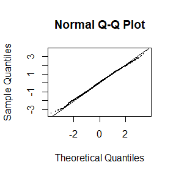

```r
 qqnorm(l$res, cex = 0.25)
 qqline(l$res)
```

The QQ plot of residuals is consistent with the normal error assumption of the linear model.So we may accept the normality assumption.

For residual plots can be generated as shown below.

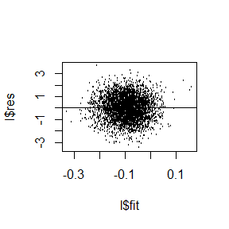

```r
 plot(l$fit, l$res, cex = 0.25)
 abline(h = 0)
```

The plot of residuals vs fits suggests that the error variance is constant as it dosen’t have any tendency .

Use the Gelman-Rubin method to monitor convergence of the chain:

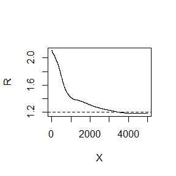

```r
N <- 6000 #length of chain
b <- 1000 #burn-in length
X <- matrix(0, N, 2) #the chain, a bivariate sample
rho <- .9 #correlation
mu1 <- 0
mu2 <- 0
sigma1 <- 1
sigma2 <- 1
x01<-c(-1.5,-0.5,0,1,2) #initialize
x02<-c(-1.5,-0.5,0,1,2)
n<-5
    #choose overdispersed initial values
set.seed(23456)
    x <- matrix(0, nrow=n, ncol=N)
    y <- matrix(0, nrow=n, ncol=N)
    for (i in 1:n)
       {
      x[i,] <- NG(N,mu1,mu2,sigma1,sigma2,rho,x01[i],x02[i])$X1
      y[i,] <- NG(N,mu1,mu2,sigma1,sigma2,rho,x01[i],x02[i])$Y1}
   psi1 <- t(apply(x, 1, cumsum))
   psi2 <- t(apply(y, 1, cumsum))
    for (i in 1:nrow(psi1))
        {psi1[i,] <- psi1[i,] / (1:ncol(psi1))
         psi2[i,] <- psi2[i,] / (1:ncol(psi2))
         }
      #plot the sequence of R-hat statistics
    rhat1 <- rep(0, N)
    rhat2 <- rep(0, N)
    for (j in (b+1):N)
        {rhat1[j] <- Gelman.Rubin(psi1[,1:j])
        rhat2[j] <- Gelman.Rubin(psi2[,1:j])
    }
    plot(rhat1[(b+1):N], type="l", xlab='X', ylab="R")
    abline(h=1.2, lty=2)
```

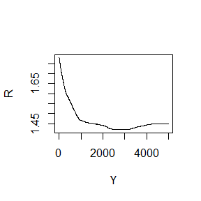

```r
    plot(rhat2[(b+1):N], type="l", xlab='Y', ylab="R")
    abline(h=1.2, lty=2)
```

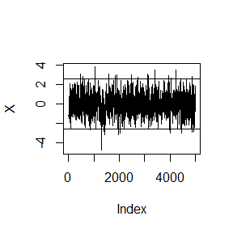

```r
N <- 6000 #length of chain
b <- 1000 #burn-in length
X <- matrix(0, N, 2) #the chain, a bivariate sample
rho <- .9 #correlation
mu1 <- 0
mu2 <- 0
sigma1 <- 1
sigma2 <- 1
x2 <- NG(N,mu1,mu2,sigma1,sigma2,rho,0,0)$X1
y2 <- NG(N,mu1,mu2,sigma1,sigma2,rho,0,0)$Y1
    refline <- qt(c(.025, .975), df=n)
    c1<-x2[(b+1):N]
        plot(c1, type="l",
             ylab="X", ylim=range(c1))
        abline(h=refline)
```

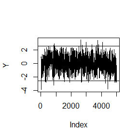

```r
    c2<-y2[(b+1):N]
    plot(c2, type="l",
             ylab="Y", ylim=range(c2))
        abline(h=refline)
```

###A-22001-2022-11-04

### HW1

The test of Intermediary effect

$$H_0:
\alpha\beta=0 \leftrightarrow H_1:\alpha\beta\neq0$$
the test statistics is
$$T=\frac{\hat{\alpha}\hat{\beta}}{\hat{se}(\hat{\alpha}\hat{\beta})}$$
Design a randomized simulation experiment,consider the performance of the above three permutation test methods.

Consider the model:

$$M=a_M+\alpha X+e_M$$

$$Y=a_Y+\beta M+\gamma X+e_Y$$
$e_M,e_Y\sim N(0,1)$

How to design the permutation that we can proof :

$$(1)\alpha=0$$
$$(2)\beta=0$$
$$(3)\alpha=0 and \beta=0$$

when we consider that:

$$① \alpha=0,\beta=1;
② \alpha=1,\beta=0;③\alpha=0,\beta=0$$

**Solution.**

```r
library(mediation)
set.seed(2345)
N=50
em<-rnorm(N)
ey<-rnorm(N)
X<-rnorm(N)
r=1
am=1
ay=2

per <- function(z, ix, dims) {
p <- dims[1]
q <- dims[2]
d <- p + q
x <- z[ 1:p,]
y <- z[-(1:p),ix]
return(c(X1=x,Y1=y)) }

#for only X independent with M;
perm1<-function(X,M,Y,n){
  a<-lm(M~X)
  b<-lm(Y~M+X)
  re=mediate(a,b,treat='X',mediator='M',sims=20)
  c=re$d0
  se=sd(re$d0.sim)
  T0=c/se
  i=1
  t<-numeric(n)
  for(i in 1:n){
    X<- sample(X);
    k <- sample(1:length(Y))
    Y <- Y[k];
    M <- M[k];
    a<-lm(M~X)
    b<-lm(Y~M+X)
    re=mediate(a,b,treat='X',mediator='M',sims=20)
    c=re$d0
    se=sd(re$d0.sim)
    t[i]=c/se
  }
  p=mean(abs(c(T0,t))>=abs(T0))
  return(p)
}


#for only M independent with Y;
perm2<-function(X,M,Y,n){
  a<-lm(M~X)
  b<-lm(Y~M+X)
  re=mediate(a,b,treat='X',mediator='M',sims=20)
  c=re$d0
  se=sd(re$d0.sim)
  T0=c/se
  i=1
  t<-numeric(n)
  for(i in 1:n){
    k <- sample(1:length(X))
    X <- X[k];
    M <- M[k];
    Y<- sample(Y);
    a<-lm(M~X)
    b<-lm(Y~M+X)
    re=mediate(a,b,treat='X',mediator='M',sims=100)
    c=re$d0
    se=sd(re$d0.sim)
    t[i]=c/se
  }
  p=mean(abs(c(T0,t))>=abs(T0))
  return(p)
}


#for X independent with M;M independent with y
perm3<-function(X,M,Y,n){
  a<-lm(M~X)
  b<-lm(Y~M+X)
  re=mediate(a,b,treat='X',mediator='M',sims=20)
  c=re$d0
  se=sd(re$d0.sim)
  T0=c/se
  i=1
  t<-numeric(n)
  for(i in 1:n){
    X<- sample(X);
    M<-M
    Y<-sample(Y);
    a<-lm(M~X)
    b<-lm(Y~M+X)
    re=mediate(a,b,treat='X',mediator='M',sims=20)
    c=re$d0
    se=sd(re$d0.sim)
    t[i]=c/se
  }
  p=mean(abs(c(T0,t))>=abs(T0))
  return(p)
}
```

$① \alpha=0,\beta=1;$:

```r
n=100
alpha=0;beta=1;
M<-am+alpha*X+em
Y<-ay+beta*M+r*X+ey
p1=perm1(X,M,Y,n)#model1
p2=perm2(X,M,Y,n)#model2
p3=perm3(X,M,Y,n)#model3
c(p1,p2,p3)
```

```
## [1] 0.77227723 0.03960396 0.34653465
```

$② \alpha=1,\beta=0;$

```r
n=50
alpha=1;beta=0;
M<-am+alpha*X+em
Y<-ay+beta*M+r*X+ey
p1=perm1(X,M,Y,n)#model1
p2=perm2(X,M,Y,n)#model2
p3=perm3(X,M,Y,n)#model3
c(p1,p2,p3)
```

```
## [1] 0.5490196 0.5294118 0.1176471
```

$③\alpha=0,\beta=0$

```r
n=50
alpha=0;beta=0;
M<-am+alpha*X+em
Y<-ay+beta*M+r*X+ey
p1=perm1(X,M,Y,n)#model1
p2=perm2(X,M,Y,n)#model2
p3=perm3(X,M,Y,n)#model3
c(p1,p2,p3)
```

```
## [1] 0.4117647 0.4705882 0.8235294
```

### HW2

Consider the model:

$$P(Y_1|X_1,X_2,X_3)=expit(\alpha+b_1X_1+b_2X_2+b_3X_3)$$

$X_1\sim P(1)$,$X_2\sim Exp(1)$,$X_3\sim B(1,0.5)$

Write a function which we imput $N,b_1,b_2,b_3,f_0$ then we may get the output $\alpha$

We use the function and choose $N=10^6,b_1=0,b_2=1,b_3=-1$

$f_0=0.1,0.01,0.001,0.0001$

graph the scatter plot of $f_0$ vs $\alpha$

**Solution.** Write the function which can help us calculate $\alpha$:

```r
set.seed(12345)
x1 <- rpois(N,1);x2<-rexp(N,1); x3 <- rbinom(N,1,0.5)
s<-function(x1,x2,x3,N,f0){
g <- function(alpha){
tmp <- exp(-alpha-b1*x1-b2*x2-b3*x3)
p <- 1/(1+tmp)
mean(p) - f0
}
solution <- uniroot(g,c(-15,5))
round(unlist(solution),5)[1:3]
return(solution$root)
}
```

Choose $N=10^6,b_1=0,b_2=1,b_3=-1$

$f_0=0.1,0.01,0.001,0.0001$,then have $\alpha$ solved as follows:

```r
N <- 1e6; b1 <- 0; b2 <- 1;b3<- -1;
alpha<-numeric(4)
f1<-c(0.1,0.01,0.001,0.0001)
i=1
for(i in 1:4)
{
  f0<-f1[i]
alpha[i] <- s(b1,b2,b3,N,f0)
i=i+1
}
alpha
```

```
## [1]  -4.197234  -6.595120  -8.906759 -11.210242
```

graph the scatter plot of $f_0$ vs $\alpha$:

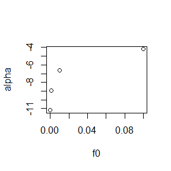

```r
plot(f1,alpha,xlab='f0')
```

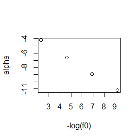

```r
plot(-log(f1),alpha,xlab='-log(f0)')
```

It can be noted that $\alpha$ increases along with $f_0$,and decrease with $-log(f_0)$.

###A-22001-2022-11-11

### Class Work

$X_1,……,X_n$ $\sim_{iid}$ $Exp(\lambda)$.With some information missed ,we just know that $X_i\in (u_i,v_i)$,where $u_i<v_i$,and they are constant.

(1)Maximize the likelihood function of observation and use EM algorithm to estimate $\lambda$ .Prove both of them are equal.

(2)We have some observation(n=10):(11,12),(8,9),(27,28),(13,14),(16,17),(0,1),(23,24),(10,11),(24,25),(2,3).Use them realize two methods show above to estimate $\lambda$.

**Solution.**

The likelihood function with observation:

$$L_o(\lambda)=\prod_{i=1}^{n}P(u_i<X_i<v_i)=\prod_{i=1}^{n}(e^{-\lambda
u_i}-e^{-\lambda v_i})$$
The log-likelihood function:

$$l_o(\lambda)=\sum_{i=1}^{n}log(e^{-\lambda
u_i}-e^{-\lambda v_i})$$
Derive $l_o$ with respect to $\lambda$ and equal to 0,Then the MLE of $\lambda$ is the solution of the equation shown as follows:

$$\sum_{i=1}^{n}\frac{v_ie^{-\lambda
v_i}-u_ie^{-\lambda u_i}}{e^{-\lambda u_i}-e^{-\lambda v_i}}=0$$
While this equation is hardly to solve ,we may choose EM:

The likelyhood function with completed data:

$$L_c(\lambda)=\prod_{i=1}^{n}
f(X_i)=\lambda^{n}e^{-\sum_{i=1}^{n}\lambda X_i}$$
The log- likelyhood function:

$$l_c(\lambda)=nlog(\lambda)-\sum_{i=1}^{n}\lambda
X_i$$
E-step:We may maximize the conditional expectation of $l_c(\lambda)$:

$$E_{\lambda^{0}}(l_c(\lambda)|u_i<X_i<v_i,i=1…n)=nlog(\lambda)-\sum_{i=1}^{n}\lambda
\hat{X_i}$$
Where $\hat{X_i}=E_{\lambda^{0}}(X_i|u_i<X_i<v_i,i=1…n)$

M-step:We can derive that:

$$\lambda^{(1)}=\frac{n}{\sum_{i=1}^{n}\hat{X_i}}$$
repeat that until the error small enough so that $\lambda$ convergence.

We may need to calculate $\hat{X_i}$:

since
$$\hat{X_i}=E_{\lambda^{0}}(X_i|u_i<X_i<v_i,i=1…n)$$

$$f(x|u_i<X_i<v_i,\lambda^{0})=\frac{\lambda^{0}e^{-\lambda^{0}x}I_{[u_i,v_i]}}{e^{-\lambda^{0}
u_i}-e^{-\lambda^{0} v_i}}$$
$$\hat{X_i}=\int
xf(x|u_i<X_i<v_i,\lambda^{0})dx=\frac{u_ie^{-\lambda^{0}
u_i}-v_ie^{-\lambda^{0} v_i}}{e^{-\lambda^{0} u_i}-e^{-\lambda^{0}
v_i}}+\frac{1}{\lambda^0}$$
then
$$\lambda^{(k+1)}=\frac{n\lambda^{(k)}}{\sum_{i=1}^{n}(\lambda^{(k)}\frac{u_ie^{-\lambda^{(k)}
u_i}-v_ie^{-\lambda^{(k)} v_i}}{e^{-\lambda^{(k)} u_i}-e^{-\lambda^{(k)}
v_i}}+1)}$$
We may assume $\lim\lambda^{(k)}=\lambda$

then
$$\lambda=\frac{n\lambda}{\sum_{i=1}^{n}(\lambda\frac{u_ie^{-\lambda
u_i}-v_ie^{-\lambda v_i}}{e^{-\lambda u_i}-e^{-\lambda v_i}}+1)}
\Rightarrow \sum_{i=1}^{n}\frac{u_ie^{-\lambda u_i}-v_ie^{-\lambda
v_i}}{e^{-\lambda u_i}-e^{-\lambda v_i}}=0$$
It means $\lambda^{(k)}$ is convergence,and it may converge to $\lambda_{ML}$ ,which satisfies $\sum_{i=1}^{n}\frac{u_ie^{-\lambda u_i}-v_ie^{-\lambda v_i}}{e^{-\lambda u_i}-e^{-\lambda v_i}}=0$

We may have the recursive :

$$\lambda^{(k+1)}=\frac{n}{\sum_{i=1}^{n}(\frac{u_ie^{-\lambda^{(k)}
u_i}-v_ie^{-\lambda^{(k)} v_i}}{e^{-\lambda^{(k)} u_i}-e^{-\lambda^{(k)}
v_i}}+\frac{1}{\lambda^{(k)}})}=f(\lambda^{k})$$
Then

$$\frac{df(x)}{dx}=\frac{n(\sum_{i=1}^{n}\frac{(u_i^2e^{-x
u_i}-v_i^2e^{-x v_i})(e^{-x u_i}-e^{-x v_i})+(u_ie^{-x u_i}-v_ie^{-x
v_i})^2}{(e^{-x u_i}-e^{-x
v_i})^2}+\frac{1}{x^2})}{(\sum_{i=1}^{n}(\frac{u_ie^{-x u_i}-v_ie^{-x
v_i}}{e^{- xu_i}-e^{-x v_i}}+\frac{1}{x}))^2}$$
we may have $0<f^{'}(x)<\frac{1}{n}<1$ since $\sum_{i=1}^{n}\frac{u_ie^{-\lambda u_i}-v_ie^{-\lambda v_i}}{e^{-\lambda u_i}-e^{-\lambda v_i}}\rightarrow0$ then under the contraction mapping theorem:

$$|\lambda^{k+1}-\lambda^{k}|\leq|f^{'}(x)|
|\lambda^{k}-\lambda^{k-1}|\leq|f^{'}(x)|^{k}
|\lambda^{1}-\lambda^{0}|\rightarrow0$$
While $n\rightarrow0$.i.e. $\lambda^{k}$ estimated by EM algorithm convergence to $\hat{\lambda}_{ML}$ estimated by ML.

(2).

Estimate $\lambda$ by two methods with 10 observed data：

```r
library(stats4)
u=c(11,8,27,13,16,0,23,10,24,2)
v=c(12,9,28,14,17,1,24,11,25,3)
lo<-function(lambda){
  sum=0
  i=1
  for(i in 1:10){
    sum=sum+(v[i]*exp(-lambda*v[i])-u[i]*exp(-lambda*u[i]))/(exp(-lambda*u[i])-exp(-lambda*v[i]))
    i=i+1
  }
  sum
}
sol <- uniroot(lo,c(0,5))
sol
```

```
## $root
## [1] 0.07196821
##
## $f.root
## [1] 0.01019994
##
## $iter
## [1] 10
##
## $init.it
## [1] NA
##
## $estim.prec
## [1] 6.103516e-05
```

EM:

```r
lambda0=1
e=1
n=10

while (e>10^(-6)){
  lambda=n/(-lo(lambda0)+n/lambda0)
  e=abs(lambda-lambda0)
  lambda0=lambda
}
lambda0
```

```
## [1] 0.0719735
```

We estimate $\lambda$ by using ML function is 0.07196821; and EM algorithm is 0.0719735.Both of them are quite closed.

```r
rm(list=ls())
```

### Exercise 2.1.3(4)

Why do you need to use unlist() to convert a list to an atomic vector? Why doesn’t as.vector() work?

**Solution.**

We need to get rid of the nested structure.

Where possible the list elements are coerced to a common mode during the unlisting, and so the result often ends up as a character vector. Vectors will be coerced to the highest type of the components in the hierarchy NULL < raw < logical < integer < double < complex < character < list < expression: pairlists are treated as lists.

A list is a (generic) vector, and the simplified vector might still be a list (and might be unchanged). Non-vector elements of the list (for example language elements such as names, formulas and calls) are not coerced, and so a list containing one or more of these remains a list. (The effect of unlisting an lm fit is a list which has individual residuals as components.) Note that unlist(x) now returns x unchanged also for non-vector x, instead of signalling an error in that case.

### Exercise 2.1.3(5)

Why is 1 == “1” true? Why is -1 < FALSE true? Why is “one” < 2 false?

**Solution.** These are all functions which coerco their arguments to character , double and character.

1 == “1” is TRUE

“FALSE==0” is TRUE then -1 < FALSE true

‘one’ comes after ‘2’ in ASCⅡ

### Exercise 2.3.1(1)

What does dim() return when applied to a vector?

**Solution.**

it may return ” NULL ”